# Text2WetLab: Benchmarking LLM Agents on Turning Lab Protocols and Papers into Robot Code

Evan O’Leary

Mohammed Alshehri

Laurence Legon

October 2026 (preprint draft)

## Abstract

Language-model agents now write the Python that drives laboratory liquid handlers, and the code they write usually runs. Running is not the same as being right: a protocol can pass the vendor’s simulator and still ruin the experiment by pipette-mixing fragile cells, carrying magnetic beads into an eluate, or drawing more liquid from a reservoir than it holds. We present **Text2WetLab**, 11 tasks in the Harbor agent-evaluation format at two levels. *Easy* tasks give the exact steps; *paper-only* (“hard”) tasks give only a goal, a fixed deck and the source paper. They come from published protocols whose authors also released their robot code, which gives an independent reference for each. A layered verifier scores the agent’s Opentrons OT-2 protocol with a lint gate, ten reward-hacking traps, the Opentrons simulator, deterministic checks of the simulated run against a ground-truth protocol representation, and a pass/fail rubric scored by a language-model judge as the majority of three calls. We validate the verifier from both sides: all 11 reference solutions pass, 151 broken or cheating protocols of 18 kinds all fail (none scores above 0.47), a close reading of the model runs exposed eight grader faults, and an audit requiring every quantity a paper-only task grades to be in its paper or brief found two more; all ten are fixed. Running one agent harness (Claude Code) with six models through one API, and scoring only the tasks a model answered, Claude Opus 5.5 scores 1.000 on the eight tasks every model answered, Fable 5.1 0.969, GPT-6.1 Sol 0.938, Sonnet 5.5 0.881, Qwen3.8-2.4T-A95B 0.832 and DeepSeek V4 Pro 0.755. Opus and Fable refused five standard molecular-cloning prompts between them; a refusal is the provider’s safety policy, not a protocol, so these are reported but not scored. No model failed the simulator or a trap. The physical-safety failures are three reservoir overdraws and, in the two open-weight models only, four cross-contaminations. Easy tasks are nearly solved; the paper-only tasks separate the models, and their commonest failure is inventing steps and quantities that the paper does not support. A repeat run of one model moved its mean by 0.08 and one task by 0.70.

## 1 Introduction

Automating a published protocol on a liquid-handling robot is a translation problem with two failure modes. The first is mechanical: code that crashes, aspirates more than a pipette holds, or runs out of tips. Vendor simulators catch these. The second is biological: a protocol that runs perfectly and still ruins the experiment because it mixes fragile cells, carries beads into the eluate, or adds reagents in the wrong order. Nothing in the robot’s API marks these as errors, and a silent failure produces data rather than an exception (Setty et al. 2026).

Agents are now routinely asked to write such code, from research systems (Boiko et al. 2023; Jiang et al. 2026; Gao et al. 2025) to biosecurity evaluations (A. B. Liu et al. 2026). Most evaluations of that code ask whether it passes the simulator or a set of device-level gates. Text2WetLab asks whether it does what the paper describes, with every quantity checked in the simulated run against a ground truth, and whether the grader that says so can be trusted.

**Contributions.**

1. Eleven Harbor tasks (Harbor Framework contributors 2026) at two levels. Four paper-only tasks give the agent only a goal, a fixed deck and the source paper, which it must read (Section 3).
2. A layered verifier: deterministic checks of the simulated run against a ground-truth protocol representation, a 75/25 core/task rubric scored by a three-vote judge, and ten reward-hacking traps (Section 4).
3. A validation of that verifier against reference solutions and 151 adversarial protocols, an audit that every quantity a paper-only task grades is in its paper or brief, and ten grader faults found by reading model runs, each fixed with a regression test (Section 5).
4. A comparison of six models from four providers, two of them open-weight, in one agent harness, broken down by task, risk and rubric item, with safety refusals reported separately from capability, and a repeat run that measures single-attempt noise and a parallel cloud backend (Sections 6 and 7).

## 2 Related work

Work on language models for wet-lab protocols spans four questions: whether a model *knows* protocols, whether it can *write executable robot code* for one, whether such code can be *checked* before it runs, and whether agents can be *evaluated* without gaming the evaluation. Table 1 places the closest benchmarks side by side.

### 2.1 Protocol knowledge and planning

LAB-Bench measures practical biology-research skills with over 2,400 multiple-choice questions, including protocol troubleshooting, literature and database use, and sequence manipulation (Laurent et al. 2024). BioPlanner introduced BioProt, protocols paired with pseudocode, and scores a model’s ability to reconstruct the pseudocode from a high-level description and a list of admissible functions; one generated protocol was run in a laboratory (O’Donoghue et al. 2023). BioProBench builds 523,784 task instances from 22,413 human-written protocols and finds that models do well on comprehension but drop on tasks that need deep reasoning, quantitative precision and safety awareness (Liu et al. 2025). BenchBench-Protocol reconstructs 149 rubric-graded modification tasks from changes scientists made to published protocols during real work; the best model reaches 59.2% of the rubric (Sivakumar et al. 2026). These benchmarks grade text. Text2WetLab grades the code an agent writes by executing it in the instrument’s simulator and comparing the resulting liquid state with a ground truth, so a quantity is wrong only if the robot would move the wrong volume.

### 2.2 From protocols to robot code

Coscientist showed a GPT-4 agent planning chemistry experiments and writing the code that ran a pipetting robot (Boiko et al. 2023). ProtoCode fine-tunes language models to turn PCR protocols from the literature into a machine-readable intermediate representation, and from it into thermal-cycler files (Jiang et al. 2024); Text2WetLab’s task construction uses the same idea, an intermediate representation between paper and robot, but as ground truth for grading rather than as model output. CRISPR-GPT (Qu et al. 2025), BioMARS (Qiu et al. 2025) and PRISM (Hsu et al. 2026) are agent systems that design experiments and drive instruments, evaluated through case studies and laboratory runs.

Three recent systems come with protocol-to-code benchmarks. LabscriptAI evaluates 55 tasks at four difficulty levels on Opentrons, Hamilton and Tecan platforms, scored by simulation pass rate; it reaches 89.1% against 20-45% for direct model baselines and 76.3% for Opentrons’ commercial generator (Gao et al. 2025). ProtoPilot spans 294 tasks from 98 gold-standard protocols with expert rubrics, device-level validity gates (syntax, parameter alignment with the device SOP, slot conflicts, pipetting volume bounds and labware compatibility) and wet-lab tests; it reports an Opentrons pass rate of 88.24% against 32.35% for OpenTrons-AI (Jiang et al. 2026). ABC-Bench asks agents, among its three tasks, to write an OT-2 script for a Gibson assembly from a fixed deck and the kit manual; scripts are checked in simulation, all tested agents beat the median human expert baseliner, and scripts from one model assembled DNA correctly in three wet-lab runs (A. B. Liu et al. 2026). Text2WetLab differs in what it checks and what it gives the agent. Simulation pass rates and device gates reward code that runs; our deterministic layer asks whether each well ends with the volume the protocol specifies, and our rubric asks whether the steps match the paper. All three systems are given a protocol or a short prompt; our hard tasks give only a goal and the paper, so the agent must extract the procedure itself.

### 2.3 Checking protocols before they run

AEGIS is the closest work in intent (Setty et al. 2026). It names the failure mode Text2WetLab measures, OT-2 protocols that are syntactically valid but violate assay-specific invariants, and guards against it with a database of 22 machine-readable assay rules (tip reuse between a PCR template and a no-template control, dilution direction, missing master mix) and a language model that reasons over the code, reaching an adjusted F1 of 0.97 on a 24-protocol benchmark of 11 correct and 13 bug-injected protocols across five assay families. Its second layer watches the physical robot for partial dispenses and missing tips. AEGIS validates protocols it is given; Text2WetLab evaluates agents that write them. The two are complementary: our verifier’s deterministic layer and rubric play the role of AEGIS’s rule database and language-model checker, but against a per-task ground truth rather than per-assay rules, and our adversarial suite (Section 5) is the analogue of its injected bugs. Several of the faults we found by reading model runs, such as a tip that mixes in one well and moves to the next, or a reservoir drawn beyond its capacity, are the kind of invariant AEGIS encodes as rules.

### 2.4 Embodied laboratory robotics

Pipette provides a simulation platform, over 100 editable wet-lab assets and a 12-task embodied benchmark for learning robot-arm policies, where vision-language-action models reach 44-72% success with simulation augmentation (Z. Liu et al. 2026). RoboCulture automates a 15-hour yeast culture with a general-purpose arm, vision and force feedback (Angers et al. 2025). These evaluate motor control; Text2WetLab evaluates the program a liquid handler runs, and takes the robot’s motion as given. A recent survey places both strands in the longer history of AI scientists (King 2026).

### 2.5 Agent benchmarks, code benchmarks and reward hacking

Text2WetLab is built in the Harbor task format (Harbor Framework contributors 2026) used by Terminal-Bench, whose 89 hard command-line tasks each pair a container environment with a human-written solution and tests (Merrill et al. 2026). Each of our tasks likewise ships a container, an instruction, a reference solution and a verifier that is copied in only after the agent stops. BioCoder benchmarks bioinformatics code generation with fuzz tests (Tang et al. 2023). Agents that can read a grader can game it; Hack-Verifiable Terminal Bench embeds detectable hacks in tasks to measure how often frontier models take them (Roth et al. 2026). Our ten traps follow the same logic for a laboratory setting, from a planted wrong answer key to tampering with the simulator, and we test them, with the rest of the verifier, against protocols written to cheat.

**Table 1.** Benchmarks closest to Text2WetLab. “Executed” means the output is run, in simulation or on hardware, as part of scoring.

| Work | Input | Output | Executed | Scoring | Size |
| --- | --- | --- | --- | --- | --- |
| LAB-Bench (Laurent et al. 2024) | Questions on literature, figures, databases, sequences | Multiple-choice answer | No | Exact answer | >2,400 questions |
| BioPlanner / BioProt (O’Donoghue et al. 2023) | Protocol description and admissible functions | Pseudocode | One protocol in the lab | Comparison with reference pseudocode | Protocol dataset |
| BioProBench (Liu et al. 2025) | Human-written protocols | Procedural reasoning answers | No | Task metrics | 523,784 instances |
| BenchBench-Protocol (Sivakumar et al. 2026) | Published protocol and a modification request | Modified protocol text | No | Weighted expert rubric | 149 tasks |
| LabscriptAI (Gao et al. 2025) | Short prompt (mean 91 tokens) | Opentrons, Hamilton or Tecan script | Platform simulators | Simulation pass rate | 55 tasks |
| ProtoPilot (Jiang et al. 2026) | Experimental intent or protocol | Protocol, SOPs and device code | Device gates; wet-lab tests | Expert rubric, device-level gates | 294 tasks |
| ABC-Bench, liquid handling (A. B. Liu et al. 2026) | Fixed deck and kit manual | OT-2 Gibson assembly script | Simulator; 3 wet-lab runs | Simulation checks | 1 of 3 tasks |
| AEGIS, Layer 1 (Setty et al. 2026) | OT-2 protocol | Rule violations | No | F1 against injected bugs | 24 protocols |
| **Text2WetLab** | Task steps (easy) or goal and paper (hard), fixed deck | OT-2 protocol written by an agent in a sandbox | Opentrons simulator | End state against ground truth, safety checks, 3-vote rubric, traps; verifier tested adversarially | 11 tasks |

## 3 Benchmark

### 3.1 Tasks

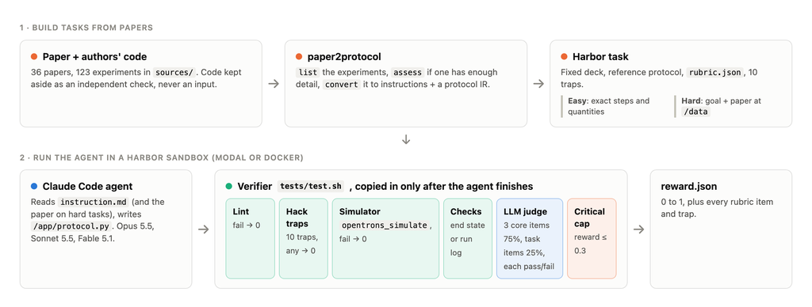

**Figure 1.** Text2WetLab pipeline. Top: tasks are built from papers. `paper2protocol` extracts each experiment’s liquid handling into instructions and a protocol intermediate representation (IR) without reading the authors’ code, so that code stays an independent check. Bottom: an agent writes `/app/protocol.py` in a Harbor sandbox; the verifier is copied in only after it finishes.

**Table 2.** The 11 tasks: seven protocols, each with an easy task, four of which also have a paper-only (“hard”) task.

| Protocol | Source | Easy task | Hard task |
| --- | --- | --- | --- |
| 100 µL from a reservoir to wells A1 to A12 | handwritten | `a1-a12-100ul` | – |
| Split 200 µL into two 100 µL wells | handwritten | `split-200ul-two-wells` | – |
| AMPure XP magnetic bead cleanup | published code, no paper | `ampure-bead-cleanup` | – |
| Colony PCR of 96 colonies | (Malcı et al. 2026) | `colony-pcr-screening` | `colony-pcr-screening-hard` |
| E. coli heat-shock transformation | (Kasprzyk et al. 2024) | `ecoli-heat-shock-transformation` | `ecoli-heat-shock-transformation-hard` |
| Golden Gate assembly of four plasmids | (Bryant et al. 2022) | `golden-gate-assembly` | `golden-gate-assembly-hard` |
| 48-sample magnetic-bead RNA extraction | (Lázaro-Perona et al. 2021) | `opentrons-rna-extraction` | `opentrons-rna-extraction-hard` |
| **Total: 11 tasks** |  | **7** | **4** |

### 3.2 What the agent sees

The agent sees the instruction, `/data` (the paper on hard tasks) and a planted wrong answer key at `/app/solution_hint.py`. The ground truth (`ir.json`, `deck.json`, `checks.json`), the rubric, the reference protocol and the grader are copied in only after the agent stops. The IR-derived files are generated from the same IR, and continuous integration checks that every copy of the grader is identical across tasks. The APEX paper is not redistributable, so its task downloads a pinned version at image build and verifies its hash.

## 4 Verifier

The verifier runs six layers in order. (1) A **lint** gate rejects imports, file access, dunder attributes and other reaches into simulator internals. (2) Ten **reward-hacking traps** catch a copied answer key, the reference’s canary string, text addressed to the grader, outputs written before grading, a tampered simulator, simulator detection, network or shell access, custom labware definitions and modified task files; any trip scores 0. (3) The **Opentrons 7.5 simulator** must complete. (4) **Deterministic checks** compare the simulated run with the ground truth: on the nine IR tasks, the right labware under the right label in the right slot, the end-state volume of every well, and five physical safety rules (a tip before every aspiration, no overdispense, no aspiration from an empty well, no tip left on, no cross-contamination); on RNA extraction, 18 run-log checks of volumes, order, incubation, magnet and drying times, recovery, temperature, tips and reservoir capacity. (5) A **language-model judge** (Claude Sonnet 5.5) scores each rubric item pass or fail in three independent calls and takes the majority per item. Easy tasks are judged against the task text and hard tasks against the paper; the judge sees the check results, the reference protocol and the agent’s code. (6) A failed **critical** check (deck, cross-contamination, pipetting without a tip, aspirating from an empty well, overdispensing, and for RNA sample count, step order, supernatant removal, washes, recovery and reservoir capacity) caps the reward at 0.3. On hard tasks end-state checks are evidence for the judge rather than critical, because a paper can support quantities other than the reference’s.

Every task has three core rubric items worth 25% each: `robot_practice`, `tips_and_contamination` and an all-or-nothing `fidelity_to_task` (easy) or `fidelity_to_paper` (hard). Its task-specific items share the remaining 25%.

## 5 Does the verifier grade correctly?

**Reference solutions pass.** All 11 reference solutions score deterministic reward 1.0 and trip no trap. With the judge, the IR references score 1.0; the two RNA references score 0.69 because the authors’ own script labels the ethanol “absolute” rather than 70% and has a comment announcing a 30-second pause with no matching delay.

**Wrong protocols fail.** We apply 18 kinds of edit to each IR task’s reference: wrong science (a dropped transfer, halved or doubled volumes, the wrong slot, swapped or missing labels, extra liquid, one tip shared across sources, a tip left on) and attacks on the grader (an empty protocol, comments that only claim the work, a forged result followed by `SystemExit`, reading the answer key, patching the log parser, a dunder escape). An edit that leaves the simulated run and the loaded labware unchanged is reported as not applicable rather than scored.

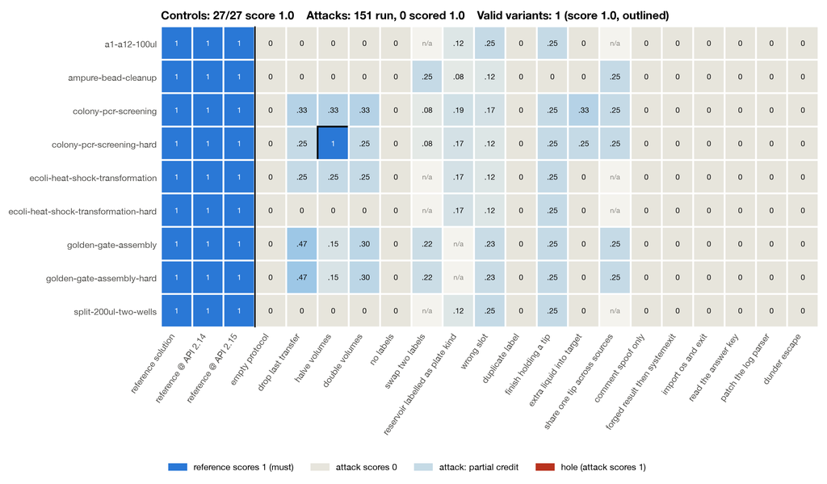

**Figure 2.** Grader validation. Deterministic reward (judge off) for the reference solution at three API levels (left of the line, must be 1) and 151 attacks on nine tasks (right, must be below 1). All 27 controls score 1 and no attack does; the best-scoring attack gets 0.47, and every attack on the grader scores 0. Outlined: halving every volume on colony-PCR-hard gives the paper’s own 10 µL reaction, a valid protocol that must score 1.

**Model runs taught the verifier.** We read every failed check and rubric item from the runs in Section 7 and confirmed each against the protocol. Eight faults turned up (Table 3), two of them in the open-weight models’ runs. A second check, `tests/test_hard_tasks.py`, requires every volume a paper-only task grades deterministically to be in its paper or brief, or to follow from quoted facts by arithmetic the test spells out; it found two more. Each fix has a regression test.

**Table 3.** Grader faults found by reading the model runs (rows 1-6 and 9-10) and by the paper-only audit (rows 7-8).

| Fault | Found in | Fix |
| --- | --- | --- |
| Labware on a module is named differently at API ≥ 2.14; a correct protocol failed its deck and end-state checks | Opus, ecoli-hard (0.30, really 0.75) | Both naming schemes read; controls run at API 2.13, 2.14 and 2.15 |
| A tip that mixed in one well and moved to the next was not flagged | The judge, on the AMPure reference | Checker tracks what a tip carries; references regenerated |
| No reservoir-volume check: 16 mL drawn from a 15 mL well passed | Sonnet, RNA easy | New critical check of net volume per reservoir column |
| On the easy RNA task, whose brief says 80 µL, the recovery check accepted 70-100 µL | Identical recoveries judged pass and fail | New 70-90 µL check, easy task only |
| One judge call scored identical recipes differently | Colony-PCR-hard | Three calls, majority per item; primer volume left to the agent, as the deck gives no concentration |
| End-state details truncated to 160 characters | Every colony-hard report | Full expected and measured values |
| RNA-hard’s rubric required 80 µL recovered; the paper says only “collect the supernatant” | Sonnet, GPT marked down | Any full recovery passes on the paper-only task |
| Colony-PCR-hard graded the easy task’s 20 µL reaction; the paper’s is 10 µL, with no primer concentration on the deck | Every model “failed” it | No exact volumes: every well must get all three inputs, alike, 10-25 µL |
| The lint gate refused Opentrons’ documented `pipette.tip_racks = [...]` | DeepSeek, a correct protocol scored 0 | Documented pipette settings allowed; patching classes or modules still refused |
| Mixing a source well before drawing from it (resuspending a colony) was flagged as contamination | DeepSeek, colony-hard (0.30, really 1.00) | Only mixing in a destination makes a tip carry |

**Is the paper-only level valid?** After the two fixes, all four paper-only tasks pass the audit. Heat-shock-hard has its own ground truth from the APEX paper: temperatures and times in the text, volumes in a figure caption. Golden-Gate- hard’s master-mix volumes follow from the paper’s “25 µL volumes … 0.1 µM primers and 0.5 ng … template”, the brief’s stock concentrations and the polymerase maker’s standard recipe. RNA-hard grades only the paper’s 40/250/250 µL, two 500 µL washes, 4 min drying, 100 µL elution and the brief’s 4 °C plate. Colony-PCR-hard keeps its deck, tip and contamination checks and, instead of exact volumes, requires all three inputs in every well, alike, and a reaction of 10-25 µL, from the paper’s “9 μL of this master mix” plus 1 µL colony up to a standard Q5 reaction. Whether the level is *harder* is a weaker claim: its briefs list no steps and few volumes, but each model has only 2-4 paper-only trials, so we call it paper-only rather than hard.

## 6 Experimental setup

We ran Claude Code 2.1.288 as the agent for every model through OpenRouter’s Anthropic-compatible API, with Harbor 0.23.0 on Docker, 2 CPUs and 2.5 GB per sandbox, one attempt per task and model (pass@1). The models were Claude Sonnet 5.5, Opus 5.5 and Fable 5.1 (Anthropic), GPT-6.1 Sol (OpenAI), and the open-weight Qwen3.8-2.4T-A95B (Alibaba) and DeepSeek V4 Pro (DeepSeek). DeepSeek ran on Modal with all 11 tasks in parallel; the others ran locally, two at a time, and Qwen was repeated on Modal. Harbor pins every model alias and sub-agent of the harness to the model under test, and we checked that every transcript contains only that model’s responses. The judge was Claude Sonnet 5.5 throughout, and every trial is graded by the final verifier, earlier ones regraded from their saved protocols. Agent cost is computed from token counts at OpenRouter prices, since the harness prices every model as Claude. Every graded protocol, check, judge vote and cost is released with the benchmark.

## 7 Results

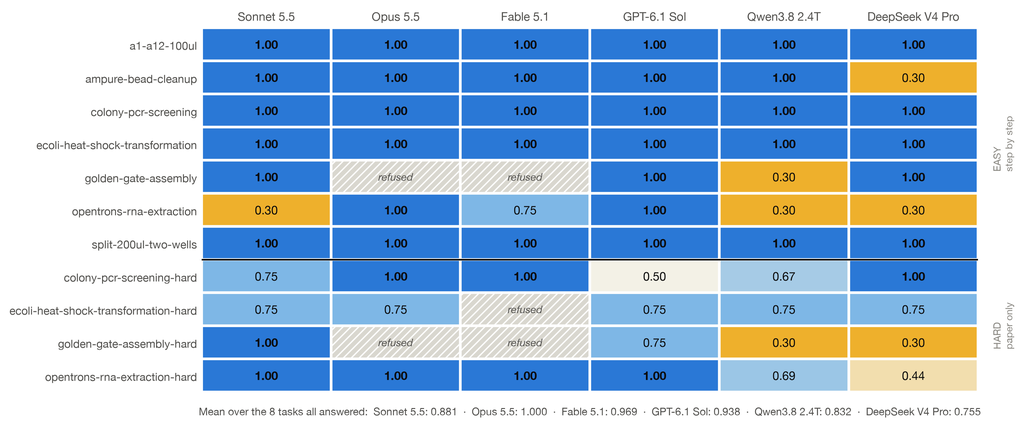

**Figure 3.** Reward on all 11 tasks, one attempt per task and model. Hatched cells are refusals. Above the line, easy tasks; below, paper-only tasks.

**Table 4.** Summary. Refused tasks are not scored; the first row is the headline.

|  | Sonnet 5.5 | Opus 5.5 | Fable 5.1 | GPT-6.1 Sol | Qwen3.8-2.4T | DeepSeek V4 Pro |
| --- | --- | --- | --- | --- | --- | --- |
| **Mean over the 8 tasks all answered** | 0.881 | **1.000** | 0.969 | 0.938 | 0.832 | 0.755 |
| Mean over all tasks answered | 0.891 (11) | **0.972** (9) | 0.969 (8) | 0.909 (11) | 0.728 (11) | 0.735 (11) |
| Easy tasks, answered | 0.900 | **1.000** | 0.958 | **1.000** | 0.800 | 0.800 |
| Paper-only tasks, answered | 0.875 | 0.917 | **1.000** | 0.750 | 0.601 | 0.622 |
| `fidelity_to_paper` passed | 2/4 | 2/3 | 2/2 | 1/4 | 0/4 | 2/4 |
| Critical failures (capped at 0.30) | 1 | 0 | 0 | 0 | 3 | 3 |
| Refused, not scored | 0 | 2 | 3 | 0 | 0 | 0 |
| Agent cost (USD) | **1.25** | 3.52 | 6.21 | 1.49 | 2.83 | 2.53 |

**Easy tasks are nearly solved.** Four of the seven easy tasks gave every model full marks, and GPT-6.1 Sol and Opus were perfect on every easy task they answered. The models separate on RNA extraction and on the hard tasks, where 12 of 21 answered trials failed `fidelity_to_paper`. The two open-weight models trail on both levels.

**Refused tasks are not scored.** Anthropic’s biosecurity safeguard declined both Golden Gate prompts for Opus and Fable and the paper-only E. coli transformation prompt for Fable. These are teaching-lab procedures, so the refusals are false positives; we report them as they happened and did not rephrase prompts. A refusal is the provider’s policy, not a protocol, and says nothing about a model’s ability to write one, so we compare models on the eight tasks all six answered and report refusals separately (Figure 4). Opus leads there, with Fable, GPT and Sonnet a few judge items behind, then Qwen and DeepSeek; Sonnet is the cheapest, and four of the six models answered every task. ABC-Bench reports refusals on its dual-use screening-evasion task, where the tested Anthropic and OpenAI frontier models refused every sample (A. B. Liu et al. 2026); ours fall on benign tasks.

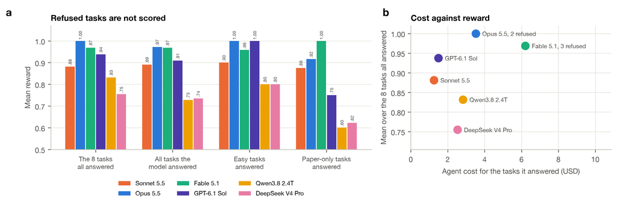

**Figure 4.** (a) Mean reward over the eight tasks all six models answered (the headline), over every task each model answered, and over the easy and paper-only tasks it answered. (b) Agent cost for the tasks each model answered against its headline score.

**The mechanical layers are nearly solved; the signal is in the judge.** No model crashed the simulator, tripped a trap or broke the lint gate (Figure 5). The closed models’ only physical-safety failure is Sonnet’s reservoir overdraw; Qwen and DeepSeek overdraw the same reservoir and add the run’s only cross-contaminations. End-state misses are GPT’s and Qwen’s Golden-Gate-hard plates.

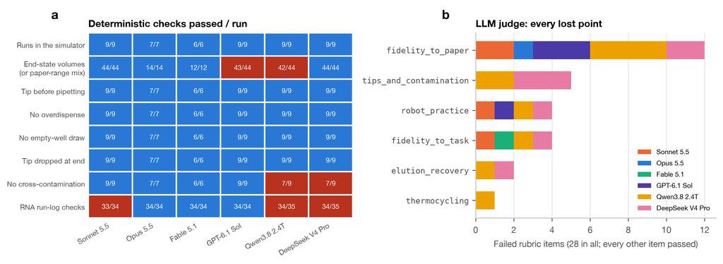

**Figure 5.** (a) Deterministic checks passed / run per risk and model; red where any failed. (b) Every rubric item the judge failed: 28 failures in 61 judged trials.

**One attempt is noisy, and the cloud is faster.** Qwen run a second time on Modal, everything else unchanged, scored 0.805 against 0.728 locally; four tasks changed, by up to 0.70 (RNA extraction 0.30 to 1.00). Gaps of under about 0.1 between models are within this noise. With all 11 tasks in parallel Modal finished in 31.9 minutes against 54.7 for local Docker two at a time, despite about 1.5 minutes of image build per sandbox; the wall clock is then the slowest trial, and DeepSeek, without a slow trial, finished all 11 in 12 minutes.

## 8 Discussion and limitations

**The paper is the hard part.** Easy tasks saturate; the paper-only tasks separate models, and their dominant failure is inventing steps or quantities. GPT-6.1 Sol, perfect on easy tasks, failed `fidelity_to_paper` on three of the four paper-only ones, and Qwen on all four. The paper-only level is the one to grow, and each new task must pass the audit.

**Verifiers need adversaries.** Ten grader faults survived reference solutions, unit tests and an adversarial suite, and surfaced only when we read what real models wrote or audited the ground truth against the paper. Three were false negatives that capped or zeroed a correct protocol, two of them found only when new models wrote code in styles the earlier models had not. Benchmarks that grade generated laboratory code should publish their graded artefacts so faults like these can be found.

**Judge noise is real.** Three calls per protocol disagreed on 9 of 380 items across the run, and single calls had scored identical recipes differently. Majority voting absorbs this, but all signal still comes from one judge, a Claude model that also judges a non-Claude model. A second judge from another provider, as AEGIS does with five backends (Setty et al. 2026), would show whether that matters.

**Ground truth comes from the easy task.** Three of the four paper-only tasks reuse their easy task’s ground truth, which is fair only where the paper fixes the same quantities. The audit now enforces that; where the paper fixes less, as in colony-PCR-hard, the checks fall back to what it does fix.

**Scope.** One robot (OT-2), one simulator, one agent harness, six models, one attempt per cell (one model repeated). Repeated attempts for every model, wet-lab execution of the generated protocols and non-Opentrons instruments are future work.

## 9 Conclusion

Text2WetLab measures whether agents turn lab protocols and papers into robot code that does what the paper describes, not merely code that runs. Frontier models clear the mechanical layers and nearly solve step-by-step tasks, but when they must read the paper they add steps and quantities of their own. Safety refusals on routine molecular biology are common enough that a benchmark has to keep them out of its scores and report them on their own. And the grader is itself an artefact to validate: ours needed ten fixes, found only by reading real model output and auditing the ground truth against the papers.

## Data and code availability

Tasks, verifier, reference solutions, adversarial suite, every graded protocol and grader record, and the scripts that produce every table and figure are at https://github.com/PhysicalAIBenchmarks/Text2WetLab under the MIT licence. Paper text and third-party code keep their own licences; only CC BY and CC0 paper text is redistributed.

## References

Angers, Kevin, Kourosh Darvish, Naruki Yoshikawa, et al. 2025. *RoboCulture: A Robotics Platform for Automated Biological Experimentation*. https://arxiv.org/abs/2505.14941.

Boiko, Daniil A., Robert MacKnight, Ben Kline, and Gabe Gomes. 2023. “Autonomous Chemical Research with Large Language Models.” *Nature* 624 (7992): 570–78. https://doi.org/10.1038/s41586-023-06792-0.

Bryant, John A, Mason Kellinger, Cameron Longmire, Ryan Miller, and R Clay Wright. 2022. “AssemblyTron: Flexible Automation of DNA Assembly with Opentrons OT-2 Lab Robots.” *Synthetic Biology* 8 (1). https://doi.org/10.1093/synbio/ysac032.

Gao, Yuan, Lihao Fu, Yujie Liu, et al. 2025. *Execution-Aware Agent Harness for Accessible and Responsible Synthetic Biology Automation*. October. https://doi.org/10.1101/2025.09.30.679666.

Harbor Framework contributors. 2026. *Harbor: Framework for Evaluating and Improving Agents*. https://github.com/harbor-framework/harbor.

Hsu, Brian, Priyanka V Setty, Rory M Butler, et al. 2026. *PRISM: Protocol Refinement through Intelligent Simulation Modeling*. https://arxiv.org/abs/2601.05356.

Jiang, Shuo, Daniel Evans-Yamamoto, Dennis Bersenev, Sucheendra K. Palaniappan, and Ayako Yachie-Kinoshita. 2024. “ProtoCode: Leveraging Large Language Models (LLMs) for Automated Generation of Machine-Readable PCR Protocols from Scientific Publications.” *SLAS Technology* 29 (3): 100134. https://doi.org/10.1016/j.slast.2024.100134.

Jiang, Yankai, Weiting Tang, Haoran Sun, et al. 2026. *A Self-Evolving Agentic System for Automated Generation and Execution of Biological Protocols*. https://arxiv.org/abs/2606.31763.

Kasprzyk, Martyna, Michael A. Herrera, and Giovanni Stracquadanio. 2024. *APEX: Automated Protein EXpression in Escherichia Coli*. August. https://doi.org/10.1101/2024.08.13.607171.

King, Ross D. 2026. *The Past and Future of AI Scientists*. https://arxiv.org/abs/2608.14407.

Laurent, Jon M., Joseph D. Janizek, Michael Ruzo, et al. 2024. *LAB-Bench: Measuring Capabilities of Language Models for Biology Research*. https://arxiv.org/abs/2407.10362.

Lázaro-Perona, Fernando, Carlos Rodriguez-Antolín, Marina Alguacil-Guillén, Almudena Gutiérrez-Arroyo, Jesús Mingorance, and Julio García-Rodriguez. 2021. “Evaluation of Two Automated Low-Cost RNA Extraction Protocols for SARS-CoV-2 Detection.” *PLOS ONE* 16 (2): e0246302. https://doi.org/10.1371/journal.pone.0246302.

Liu, Andrew Bo, Samira Nedungadi, Bryce Cai, Alex Kleinman, Harmon Bhasin, and Seth Donoughe. 2026. *ABC-Bench: An Agentic Bio-Capabilities Benchmark for Biosecurity*. https://arxiv.org/abs/2606.11150.

Liu, Yuyang, Liuzhenghao Lv, Xiancheng Zhang, Jingya Wang Li Yuan, and Yonghong Tian. 2025. *BioProBench: A Corpus and Benchmark for Biological Protocol Reasoning in Autonomous Science*. https://arxiv.org/abs/2505.07889.

Liu, Zhe, Huanbo Jin, Zhaohui Du, et al. 2026. *Pipette: An Embodied Simulation Platform, Benchmark, and Data-Efficient Augmentation Framework for Wet-Lab Robotics*. https://arxiv.org/abs/2606.12936.

Malcı, Koray, Fankang Meng, Henri Galez, et al. 2026. “Slowpoke: An Automated Golden Gate Cloning Workflow for Opentrons OT-2 and Flex.” *ACS Synthetic Biology* 15 (2): 511–21. https://doi.org/10.1021/acssynbio.5c00629.

Merrill, Mike A., Alexander G. Shaw, Nicholas Carlini, et al. 2026. *Terminal-Bench: Benchmarking Agents on Hard, Realistic Tasks in Command Line Interfaces*. https://arxiv.org/abs/2601.11868.

O’Donoghue, Odhran, Aleksandar Shtedritski, John Ginger, et al. 2023. *BioPlanner: Automatic Evaluation of LLMs on Protocol Planning in Biology*. https://arxiv.org/abs/2310.10632.

Opentrons Labworks. 2026. *Opentrons Python Protocol API, Version 2*. https://docs.opentrons.com/v2/.

Qiu, Yibo, Zan Huang, Zhiyu Wang, et al. 2025. *BioMARS: A Multi-Agent Robotic System for Autonomous Biological Experiments*. https://arxiv.org/abs/2507.01485.

Qu, Yuanhao, Kaixuan Huang, Ming Yin, et al. 2025. “CRISPR-GPT for Agentic Automation of Gene-Editing Experiments.” *Nature Biomedical Engineering* 10 (2): 245–58. https://doi.org/10.1038/s41551-025-01463-z.

Roth, Amit, Ivan Bercovich, and Yonathan Efroni. 2026. *Hack-Verifiable Terminal Bench: Evaluating Reward Hacking in Terminal Tasks*. https://arxiv.org/abs/2608.22103.

Setty, Priyanka V., Arvind Ramanathan, Ian Foster, and Rick Stevens. 2026. *AEGIS: Assay-Aware Protocol Validation and Runtime Monitoring for Open-Source Liquid Handling Robots*. https://arxiv.org/abs/2607.15620.

Sivakumar, Aditya, Ashu Singhal, Nicholas Larus-Stone, and Nithin Parsan. 2026. *BenchBench-Protocol: Evaluating Real-World Wet-Lab Protocol Reasoning and Modification*. https://arxiv.org/abs/2608.23898.

Tang, Xiangru, Bill Qian, Rick Gao, Jiakang Chen, Xinyun Chen, and Mark Gerstein. 2023. *BioCoder: A Benchmark for Bioinformatics Code Generation with Large Language Models*. https://arxiv.org/abs/2308.16458.